# Multivariate Data Analysis - chapter 05

# 5.다차원척도법(MDS)

## 1. MDS란?

- MDS(Multi Dimensional Scaling):  
  개체들을 대상으로 특성(변수)들을 측정해 그 특성을 이용하여 개체들 사이의 유사성(similarity)/비유사성(dissimilarity)을 측정한 후에 개체들을 다차원 공간상에 점으로 표현하는 방법
  - 일반적으로 개체들을 2-차원 또는 3차원 공간상에 점으로 표현하는데, 개체들의 공간상의 위치에 따라 개체들 사이의 관계를 파악함.
  - 유사한 개체들 사이의 군집화 문제에 널리 이용됨.
  - 경제/사회적으로 서울과 가장 가까운 도시는 어디이고, 가장 먼 도시는 어디이며, 11개 도시들 중에서 유사성이 가장 높은 두 도시는 어디인가 등에 대한 정보를 구할 수 있음.

## 2. MDS 분석과정

### 제1단계 : 자료수집

- n개의 개체들을 대상으로 p개의 특성(변수)을 측정

### 제2단계: 유사성/비유사성 측정

- 관측한 변수들을 이용하여 개체들 사이의 유사성/비유사성을 측정
  - 유사성: 측정한 값이 클수록 두 개체의 사이의 관계가 가깝다는 것을 의미하는 것으로 대표적인 유사성 측정방법으로 `상관계수`가 있음
  - 비유사성: 측정된 값이 클수록 두 개체 사이의 관계가 멀고, 작을 수록 두 개체의 사이의 관계가 가깝다는 것을 의미하며, 대표적인 비유사성 측정방법으로는 유클리디안 거리(Euclidean distance)가 이용됨.

### 제3단계: 2-차원/3차원 공간상에 개체 표현

- 개체들 사이의 유사성/비유사성 자료를 구한 후에는 이 자료를 이용하여 개체들을 2-차원/3-차원 공간상에 점으로 표현

### 제4단계 : 최적표현의 결정

- 개체들을 2-차원 공간상에 표현하고자 하는 경우에는 개체들 사이의 원래의 비유사성 정도를 가장 잘 표현하는 개체들의 위치를 구해야함.
- 이 경우 반복과정을 통하여 최적 위치를 구해 나가는데, 영의 스트레스(Young’s Stress) 또는 S-스트레스(S-Stress)를 이용하여 표현된 최적위치의 적합성을 측정함. 스트레스 또는 S-스트레스는 2-차원상에 표현된 개체들의 상호 위치관계가 원래 개체들 사이의 상호 간에 구해진 비유사성 정도에 어느 정도 적합한 가를 측정하는 기준이 됨.

## 3. 비유사성(거리)의 측정

### 구간척도/비율척도 자료의 비유사성

- 구간척도 또는 비율척도로 측정된 자료를 이용한 개체들 사이의 비유사성 측정은 거리(distance) 측정방법을 이용
- 일반적으로 이용되고 있는 유클리디안(Euclidean) 거리, 체비셰프(Chebyshev) 거리, 맨해튼(Manhattan) 거리 등과 같은 방법을 이용하여 구함
- 거리에서 측정단위에 의한 영향력을 없애기 위해서 변숫값들을 표준화한 후에 거리를 측정하는 것이 일반적임.

### 이항자료의 비유사성 측정

- 이항자료란 각 개체를 대상으로 특성이 ’있다/없다’를 측정한 자료로 특성이 있으면 1, 없으면 0으로 기록. p개의 변수(특성)에 대한 두 개체의 관측자료는 [표 5-1]과 같음

  [표 5-1]

  | 개체 \ 변수 | $X_1$ | $X_2$ | $X_3$ | … | $X_p$ |
  | --- | --- | --- | --- | --- | --- |
  | 1 | 1 | 1 | 0 | … | 0 |
  | 2 | 0 | 1 | 1 | … | 1 |

- 2 x 2 분할표 작성

  [표 5-2]

  | 구분 | [개체2] 1 | [개체2] 0 | 합 |
  | --- | --- | --- | --- |
  | [개체1] 1 | a | b | a + b |
  | [개체2] 0 | c | d | c + d |
  | 합 | a+c | b+d | a+b+c+d |

  a: [개체1]과 [개체2] 모두 1인 쌍의 수  
  b: [개체1]은 1이고 [개체2]는 0인 쌍의 수  
  c: [개체1]은 0이고 [개체2]는 1인 쌍의 수  
  d: [개체1]과 [개체2] 모두 0인 쌍의 수
- 분할표를 이용하여 이항자료에 대한 거리측정
  - 유클리디안 거리: $\delta_{12} = \sqrt{b+c}$
  - 유클리디안 제곱거리: $\delta_{12} = (b+c)$
  - 크기차이(size difference): $\delta_{12} = {(b-c)^2 \over (a+b+c+d)^2}$
  - pattern difference: $\delta_{12} = {bc\over (a+b+c+d)^2}$
  - variance : $\delta_{12} = {b+c \over 4(a+b+c+d)}$

## 4. MDS 분석

### 메트릭 MDS

- n개의 개체가 있을 때 n x n 거리행렬 D를 구함. 여기서 $\delta_{ij}$ 는 개체 i와 개체 j 사이의 거리를 의미함.
- 거리행렬 D를 이용하여 n개의 개체들을 보다 낮은 차원인 k-차원에 점으로 표현

### 표현기준 : 주어진 거리행렬을 k-차원 공간의 점으로 표현

스트레스(Stress) : $S_{ij}$ 를 k-차원 공간상에서의 개체 i와 개체 j의 거리라고 하고, $\hat{S}_{ij}$ 를 측정모형에서 구한 $S_{ij}$ 의 적합값이라고 할 때 형상화의 적절성을 판단하는 최적화 기준을 스트레스라고 함. 스트레스는 부적합도기준(badness of fit criterion)으로 사용됨.
$$\begin{aligned}Stress &= \sqrt{ \sum_{i<j}
(d_{ij}-\delta_{ij})^2 \over \sum_{i<j} d_{ij}^2} \\ &d_{ij}:
좌표상의 상대적 거리 \\ &\delta_{ij}: 원래의 거리
\end{aligned}$$

### 스트레스의 해석

- 스트레스는 표현공간의 차원이 클수록 작아짐. 극단적으로 k = p이면 스트레스틑 0
- 표현공간의 차원이 클수록 결과의 해석이 복잡해지는 문제가 있음
- 따라서 일반적으로 표현공간의 차원을 2-차원 또는 3-차원 공간으로 제한함
  - 표현결과의 신뢰도를 측정하기 위하여 크루스칼(Kruskal)은 스트레스의 크기와 형상화된 표현결과의 적절성에 대하여 [표 5-3]과 같은 관계를 제시

    [표 5-3]

    | 스트레스 | 적합도 수준 |
    | --- | --- |
    | 0.20 이상 | 나쁨(poor) |
    | 0.10 | 보통(fair) |
    | 0.05 이내 | 좋음(good) |
    | 0.00 | 완벽함(perfect) |

  - 위의 기준에 의할 때 스트레스의 크기가 0.1(10%) 이상인 경우에는 표현된 결과가 원래 개체들 사이의 관계를 잘 표현하고 있다고 할 수 없으므로 스트레스의 크기가 적정수준이 되도록 차원을 높일 필요가 있음.

### 비메트릭 MDS

- 비 메트릭 MDS는 순위 MDS(Ordinal MDS)라고도 함
- 좌표상의 걸리 $d_{ij}$ 가 원래의 거리 $\delta_{ij}$ 와 같은 순위를 갖도록 배열
- 실제적으론 $d_{ij}$ 의 평활추정값(smoothed fitted distance) $\hat{d}_{ij}$ [이를 disparity(격차)라고 함]가 원래의 거리 $\delta_{ij}$ 와 똑같은 순서를 갖도록 구성
- 부적합도 스트레스

$$\begin{aligned}Stress &= \sqrt{ \sum_{i<j}
(d_{ij}-\hat{d}_{ij})^2 \over \sum_{i<j} d_{ij}^2} \end{aligned}$$

## 5. R을 이용한 MDS 분석 - 메트릭 MDS

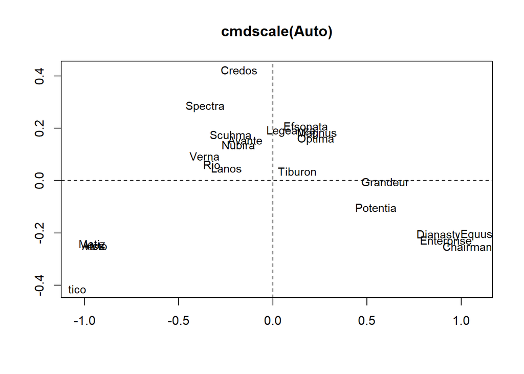

```r
auto = read.csv("./data/auto.csv")
#표준화 변수 만들기
X = auto[,-1]
autoName = auto[,1]
#z-standardization
zX = scale(X, center = TRUE, scale = TRUE)
# 0-1 transformation
maxX = apply(X, 2, max)
minX = apply(X, 2, min)
z01X = scale(X, center=minX, scale=maxX-minX)
# 거리행렬 만들기
z01X_dist = dist(z01X, method = 'euclidean')
z01X_dist = as.matrix(z01X_dist)
colnames(z01X_dist)=autoName
rownames(z01X_dist)=autoName
# cmdscale 실행
mds1 = cmdscale(z01X_dist, k=2)
plot(mds1[,1], mds1[,2], type='n', xlab='', ylab='', main='cmdscale(Auto)')
text(mds1[,1], mds1[,2], rownames(z01X_dist), cex=0.9)
abline(h=0, v=0, lty=2)
```

- 승용차종이 경차, 소형/중형, 대형 등으로 잘 구분되어 나타남
- ’Credos’가 2000cc급의 중형차인데도 다른 차들과 떨어져 나타남.  
  원인은 원 자료 파일에서 Credos의 연비가 20.8km/1이고 가격이 463만원으로 다른 중형차와 크게 다르게 관측됨.
- 각 축의 의미 : X 축은 오른쪽에 큰 차(비싼 차) 왼쪽에 경차(싼차)가 분포되어 있으므로 크기 또는 가격을 대표. Y축은 Credos가 특이하게 위치하고 있고 차체 크기에 비하여 연비가 매우 높게 관측되었으므로 차체 크기대비 연비를 대표

## 6. Python을 이용한 MDS분석

```python
import numpy as np
import pandas as pd
import matplotlib.pyplot as plt

# read data.
auto = pd.read_csv("./data/auto.csv")
# select variable
X = auto.iloc[:, 1:]
# each case name
autoName = auto["autoName"]
autoName = list(autoName)

# z-standardized
from sklearn.preprocessing import StandardScaler
zX = StandardScaler().fit_transform(X)

# 0-1 transformation
from sklearn.preprocessing import MinMaxScaler
scaler = MinMaxScaler()
z01X = scaler.fit_transform(X)

# getting distance-matrix
from sklearn.metrics import pairwise_distances
z01X_dist = pairwise_distances(z01X, metric='euclidean')
z01X_dist.shape

# execute MDS
```

```
## (23, 23)
```

```python
from sklearn.manifold import MDS
cmds = MDS(n_components=2, random_state=0, dissimilarity='precomputed')
mds1 = cmds.fit(z01X_dist)
```

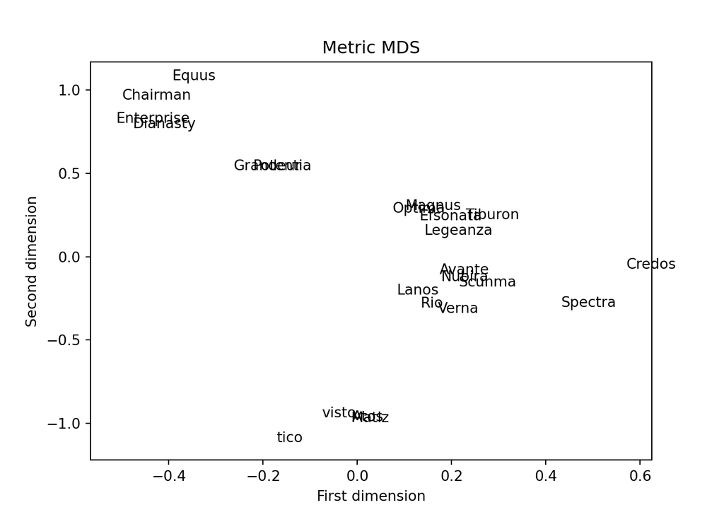

```python
mds1_coords = cmds.fit_transform(z01X_dist)

# draw
plt.figure()
plt.scatter(mds1_coords[:,0], mds1_coords[:,1], facecolors='none', edgecolors='none')
labels = autoName

# attach labels to each case of MDS
for label, x, y, in zip (labels, mds1_coords[:,0], mds1_coords[:,1]) :
  plt.annotate(label, (x,y), xycoords='data')

plt.xlabel('First dimension')
plt.ylabel('Second dimension')
plt.title('Metric MDS')
plt.show()
```